[O’Hara on GitHub](https://github.com/oharac)

# Assemble grouping traits and form Functional Entities

Compiled on Fri Sep 3 15:10:56 2021 by ohara

```r
knitr::opts_chunk$set(echo = TRUE, message = FALSE, warning = FALSE)

library(oharac)
oharac::setup()
source(here('common_fxns.R'))
```

# 1 Summary

Gather processed traits data and assemble into a dataframe. Assign bins for trait values. Use trait bins to identify functional entities (FE) per Villeger and others.

# 2 Data

See individual trait scripts.

# 3 Methods

## 3.1 Gather traits

Here we will read in each trait set and assign the values into specific bins as appropriate. Inspired by Sebastien Villeger’s code, I will create text codes for each trait/value combo, but with a few more letters so they are a little more comprehensible.

### 3.1.1 mobility traits

```r
mob_codes <- c('sessile'           = 'ses',
               'sedentary'         = 'sed',
               'mobile resident'   = 'res',
               'migratory/nomadic' = 'mig')
mob_traits <- read_csv(here('_data/traits_grouping/trait_mobility.csv')) %>%
  mutate(mob = mob_codes[value],
         mob = factor(mob, levels = mob_codes, ordered = TRUE)) %>%
  group_by(species) %>%
  filter(mob == max(mob)) %>%
  ungroup() %>%
  select(species, mob) %>%
  distinct()

# x <- show_dupes(mob_traits, 'species')

table(mob_traits$mob) %>% knitr::kable()
```

| Var1 | Freq |
| --- | --- |
| ses | 20948 |
| sed | 25314 |
| res | 29155 |
| mig | 17323 |

### 3.1.2 water column position traits

```r
trait_val_codes <- c(reef    = 'rf',
                     pelagic = 'pel',
                     benthic = 'ben',
                     benthopelagic = 'bp')
water_col_traits <- read_csv(here('_data/traits_grouping/trait_water_col_position.csv')) %>%
  mutate(wcol = trait_val_codes[value],
         wcol = factor(wcol, levels = trait_val_codes, ordered = FALSE)) %>%
  select(species, wcol) %>%
  distinct()

# x <- show_dupes(water_col_traits, 'species')


table(water_col_traits$wcol) %>% knitr::kable()
```

| Var1 | Freq |
| --- | --- |
| rf | 15064 |
| pel | 22781 |
| ben | 142868 |
| bp | 2193 |

### 3.1.3 Reproduction traits

Here we have options of:

- generation time
- fecundity
- parental investment
- planktonic larval duration
- post-birth/hatching parental dependence

Generation time and fecundity seem most important, but others can be included as separate traits as well. For spp with multiple fecundity and generation time values, take the largest category.

#### 3.1.3.1 Fecundity

```r
repr_traits <- read_csv(here('_data/traits_grouping/trait_reproduction.csv')) %>%
  filter(!is.na(value))

fecund_codes <- c('<1'         = 'lo',
                  '1-2'        = 'lo',
                  '2-5'        = 'lo',
                  '5-10'       = 'lo',
                  '10-20'      = 'med',
                  '20-50'      = 'med',
                  '50-100'     = 'med',
                  '100-1000'   = 'hi',
                  '1000-10000' = 'vhi',
                  '>10000'     = 'vhi')

fecund_traits <- repr_traits %>%
  filter(trait == 'fec') %>%
  mutate(fec = fecund_codes[value],
         fec = factor(fec, levels = unique(fecund_codes), ordered = TRUE)) %>%
  group_by(species) %>%
  filter(fec == max(fec)) %>%
  ungroup() %>%
  select(species, fec) %>%
  distinct()

table(fecund_traits$fec)
```

```
##
##    lo   med    hi   vhi
##  9791 10703 11139 40428
```

#### 3.1.3.2 Generation time

```r
gen_codes <- c("<1yr"     = 'vshort',
               "1-5yrs"   = 'short',
               "5-10yrs"  = 'med',
               "10-20yrs" = 'long',
               ">20yrs"   = 'long')

gen_time_traits <- repr_traits %>%
  filter(trait == 'age_mat') %>%
  mutate(gen = gen_codes[value],
         gen = factor(gen, levels = unique(gen_codes), ordered = TRUE)) %>%
  group_by(species) %>%
  filter(gen == max(gen)) %>%
  ungroup() %>%
  select(species, gen) %>%
  distinct()

table(gen_time_traits$gen)
```

```
##
## vshort  short    med   long
##   8172  53424  24005    855
```

#### 3.1.3.3 check correlation between gen time and fecundity

```r
gen_fec_df <- full_join(fecund_traits, gen_time_traits, by = 'species') %>%
  drop_na()

gen_fec_mtx <- gen_fec_df %>%
  group_by(gen, fec) %>%
  summarize(n = n()) %>%
  mutate(fec = paste0('f:', fec),
         gen = paste0('g:', gen)) %>%
  spread(fec, n) %>%
  column_to_rownames('gen') %>%
  as.matrix()

chi2 <- chisq.test(gen_fec_mtx, correct=F)
c(chi2$statistic, chi2$p.value)
```

```
## X-squared
##  7176.536     0.000
```

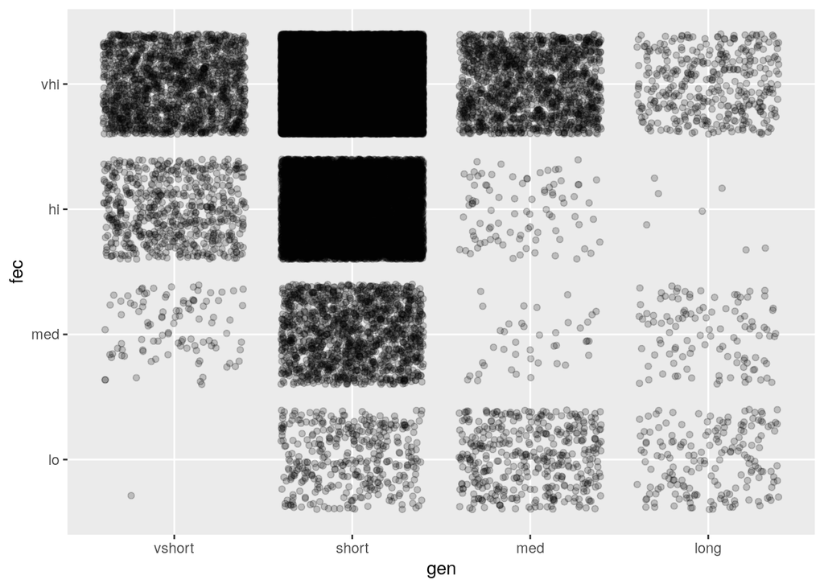

```r
ggplot(gen_fec_df, aes(x = gen, y = fec)) +
  geom_jitter(alpha = .2)
```

While there is obviously correlation, there seems to be enough variation to keep both variables in for now.

### 3.1.4 Trophic level

Similar to Mireia’s classifications: classify into primary producers (1), primary consumers (herbivores/detritivores) 2), secondary (2-3), tertiary (3-4), apex (>4). Examine potential break points to see distributions.

Some considerations:

- *Orcinus orca* is 4.6
- *Carcharodon carcharias* is 4.48
- *Oncorhynchus* spp are from 3.23 (Sockeye) to 4.18 (Coho, the only one above 4.0)

Here we set break points at the top value for each category ($\leq$ 2 = primary consumer, $\leq$ 3 = secondary consumer, $\leq$ 4 = tertiary consumer, >4 = apex consumer)

```r
troph_traits <- read_csv(here('_data/traits_grouping/trait_trophic_level.csv')) %>%
  filter(!is.na(value))

summary(troph_traits)
```

```
##    species             trait               value             sd
##  Length:170832      Length:170832      Min.   :0.000   Min.   :0.00
##  Class :character   Class :character   1st Qu.:2.055   1st Qu.:0.19
##  Mode  :character   Mode  :character   Median :2.790   Median :0.42
##                                        Mean   :2.739   Mean   :0.42
##                                        3rd Qu.:3.301   3rd Qu.:0.64
##                                        Max.   :5.000   Max.   :2.51
##                                                        NA's   :45401
##       nspp          gf_level
##  Min.   :  1.0   Min.   :1.00
##  1st Qu.:  2.0   1st Qu.:3.00
##  Median :  5.0   Median :3.00
##  Mean   : 23.7   Mean   :3.25
##  3rd Qu.: 15.0   3rd Qu.:4.00
##  Max.   :830.0   Max.   :5.00
##  NA's   :15398   NA's   :7718
```

```r
troph_qtile <- ecdf(troph_traits$value)
troph_qtile(c(2, 3, 3.5, 4, 4.4, 5))
```

```
## [1] 0.2422848 0.5883265 0.8953943 0.9673715 0.9938536 1.0000000
```

```r
troph_traits <- troph_traits %>%
  mutate(trp = case_when(value <= 2 ~ 'pri', ### anything above 2 suggests some carnivory
                         value <= 3 ~ 'sec',
                         value <= 4 ~ 'ter',
                         value > 4  ~ 'apex',
                         TRUE ~ 'oops'),
         trp = factor(trp, levels = c('pri', 'sec', 'ter', 'apex'), ordered = TRUE)) %>%
  select(species, trp) %>%
  distinct()

table(troph_traits$trp)
```

```
##
##   pri   sec   ter  apex
## 41390 59115 64753  5574
```

### 3.1.5 Max length

Examine distribution of lengths to see if there are good break points, or choose break points to achieve a reasonable distribution across reasonable size classes (~ factor of 10 for each class).

```r
length_traits <- read_csv(here('_data/traits_grouping/trait_length_cm.csv')) %>%
  filter(!is.na(value))

summary(length_traits$value)
```

```
##    Min. 1st Qu.  Median    Mean 3rd Qu.    Max.
##    0.00    1.45    4.50   12.40   10.80 4572.00
```

```r
quantile(log10(length_traits$value), c(.2, .4, .6, .8))
```

```
##        20%        40%        60%        80%
## 0.02965428 0.41497335 0.78431156 1.13534471
```

```r
length_traits <- length_traits %>%
  mutate(len = case_when(value <    1.5 ~ 'vsm', ### smaller than 1.5 cm
                         value <    5.0 ~ 'sm',  ### 1.5 - 5 cm
                         value <   15.0 ~ 'med', ### 5 - 15 cm
                         value <  150.0 ~ 'lg',  ### 15 - 150 cm
                         value >= 150.0 ~ 'vlg', ### larger than 1.5 meters
                         TRUE ~ 'oops'),
         len = factor(len, levels = c('vsm', 'sm', 'med', 'lg', 'vlg'), ordered = TRUE)) %>%
  select(species, len) %>%
  distinct()

table(length_traits$len)
```

```
##
##   vsm    sm   med    lg   vlg
## 47178 49356 54080 33770  1815
```

The number of uniquely identified species with full complement of traits will be limited by data availability in the Species Vulnerability project as well as data availability in Fishbase/Sealifebase. See individual scripts for various gapfilling and assignation of traits for each distinct trait set.

## 3.2 Assemble and assign to functional entities

Here we will full-join all trait dataframes by species, eliminate any with NA values for any traits, and then collapse the trait values together into a specific functional entity character code (which will also be assigned a numeric FE code).

```r
n_fe_possible <- n_distinct(mob_traits$mob) *
                 n_distinct(fecund_traits$fec) *
                 n_distinct(gen_time_traits$gen) *
                 n_distinct(troph_traits$trp) *
                 n_distinct(length_traits$len) *
                 n_distinct(water_col_traits$wcol)
```

Based on the given trait categories, we could see up to 5120 functional entities, though most will not be populated (e.g., not so likely to find a very large apex predator species with a high fecundity and short generation time).

### 3.2.1 Number of spp included, by class

```r
worms_spp <- assemble_worms()

all_traits_df <- mob_traits %>%
  full_join(fecund_traits, by = 'species') %>%
  full_join(gen_time_traits, by = 'species') %>%
  full_join(troph_traits, by = 'species') %>%
  full_join(length_traits, by = 'species') %>%
  full_join(water_col_traits, by = 'species') %>%
  left_join(worms_spp, by = 'species') %>%
  distinct()

incl_spp <- all_traits_df %>%
  drop_na() %>%
  group_by(class) %>%
  summarize(n_spp = n_distinct(species))

knitr::kable(incl_spp)
```

| class | n_spp |
| --- | --- |
| actinopterygii | 7999 |
| anthozoa | 319 |
| asteroidea | 2 |
| aves | 327 |
| bivalvia | 1386 |
| cephalopoda | 842 |
| crinoidea | 1 |
| demospongiae | 7519 |
| echinoidea | 9 |
| elasmobranchii | 614 |
| gastropoda | 928 |
| holothuroidea | 13 |
| malacostraca | 10912 |
| mammalia | 124 |
| myxini | 2 |
| polychaeta | 5061 |
| pycnogonida | 1133 |
| reptilia | 91 |

### 3.2.2 Number of spp with NAs for one or more traits

```r
fe_nas <- all_traits_df %>%
  select(-c(phylum:genus)) %>%
  gather(trait, val, -species) %>%
  group_by(species) %>%
  summarize(n_na = sum(is.na(val)))
table(fe_nas$n_na)
```

```
##
##     0     1     2     3     4     5
## 37282 30403 52844 37986 18429 53295
```

### 3.2.3 Number of spp unmatched by WoRMS names

```r
unmatched_taxa <- all_traits_df %>%
  filter(is.na(genus)) %>%
  select(-c(phylum:genus)) %>%
  gather(trait, val, -species) %>%
  group_by(species) %>%
  summarize(na_traits = sum(is.na(val))) %>%
  mutate(genus = str_extract(species, '[a-z]+(?= )')) %>%
  group_by(na_traits) %>%
  summarize(n_spp = n_distinct(species),
            n_gen = n_distinct(genus))
knitr::kable(unmatched_taxa)
```

| na_traits | n_spp | n_gen |
| --- | --- | --- |
| 1 | 16 | 5 |
| 2 | 161 | 44 |
| 3 | 40 | 19 |
| 4 | 29 | 13 |
| 5 | 35941 | 8044 |

```r
missing_water_col <- all_traits_df %>%
  gather(trait, val, -species, -genus) %>%
  group_by(genus, species) %>%
  summarize(n_na = sum(is.na(val)),
            missing_wcol = (is.na(val) & trait == 'wcol')) %>%
  filter(n_na == 1 & missing_wcol)

worms_genus_to_class <- worms_spp %>%
  select(class, order, family, genus) %>%
  distinct()
genus_match <- all_traits_df %>%
  filter(is.na(genus)) %>%
  select(-c(phylum:genus)) %>% ### all NAs
  mutate(genus = str_extract(species, '[a-z]+(?= )')) %>%
  mutate(genus_match = genus %in% worms_spp$genus,
         potential_fill = genus %in% missing_water_col$genus) %>%
  left_join(worms_genus_to_class, by = 'genus') %>%
  group_by(class, genus_match, potential_fill) %>%
  summarize(n_spp = n_distinct(species),
            n_gen = n_distinct(genus))
```

#### 3.2.3.1 potential fills with additional gapfilling?

Gapfilling skipped any genera represented by only one species, which may be why a few of these are still unmatched.

| class | genus_match | potential_fill | n_spp | n_gen |
| --- | --- | --- | --- | --- |
| actinopterygii | TRUE | TRUE | 2 | 2 |
| bivalvia | TRUE | TRUE | 2 | 2 |
| malacostraca | TRUE | TRUE | 9 | 9 |
| polychaeta | TRUE | TRUE | 10 | 10 |
| reptilia | TRUE | TRUE | 1 | 1 |

### 3.2.4 Check traits causing drops

Which traits are responsible for dropping most species? examine species dropped for one or two NAs.

```r
traits <- c('mob', 'fec', 'gen', 'trp', 'len', 'wcol')
fe_trait_single_na <- all_traits_df %>% gather(trait, val, all_of(traits)) %>%
  group_by(species) %>%
  filter(is.na(val)) %>%
  filter(n() == 1) %>%
  ungroup()
table(fe_trait_single_na$trait)
```

```
##
##   fec   gen   len   mob  wcol
## 16405   299   208  9717  3774
```

```r
fe_trait_double_na <- all_traits_df %>% gather(trait, val, all_of(traits)) %>%
  group_by(species) %>%
  filter(is.na(val)) %>%
  filter(n() == 2) %>%
  arrange(trait) %>%
  summarize(t1 = first(trait), t2 = last(trait)) %>%
  ungroup()
table(fe_trait_double_na %>% select(t1, t2))
```

```
##      t2
## t1      gen   mob   trp  wcol
##   fec 23321  8858     0  5163
##   gen     0 12905     1     0
##   len     0     0     3     0
##   mob     0     0     0  2593
```

```r
fe_trait_triple_na <- all_traits_df %>% gather(trait, val, all_of(traits)) %>%
  group_by(species) %>%
  filter(is.na(val)) %>%
  filter(n() == 3) %>%
  arrange(trait) %>%
  summarize(t1 = first(trait), t2 = nth(trait, 2), t3 = last(trait)) %>%
  ungroup()
table(fe_trait_triple_na %>% select(t1, t2, t3))
```

```
## , , t3 = len
##
##      t2
## t1      gen   mob
##   fec     3     0
##   gen     0     0
##
## , , t3 = mob
##
##      t2
## t1      gen   mob
##   fec 23987     0
##   gen     0     0
##
## , , t3 = trp
##
##      t2
## t1      gen   mob
##   fec   254     0
##   gen     0     0
##
## , , t3 = wcol
##
##      t2
## t1      gen   mob
##   fec  6010  2453
##   gen     0  5279
```

### 3.2.5 assign FE codes

```r
fe_df <- all_traits_df %>%
  drop_na() %>%
  mutate(fe_code = sprintf('MOB%s_FEC%s_GEN%s_TRP%s_LEN%s_WCOL%s', mob, fec, gen, trp, len, wcol)) %>%
  group_by(fe_code) %>%
  mutate(n = n()) %>%
  ungroup() %>%
  arrange(desc(n)) %>%
  mutate(fe_code = fct_inorder(fe_code))
```

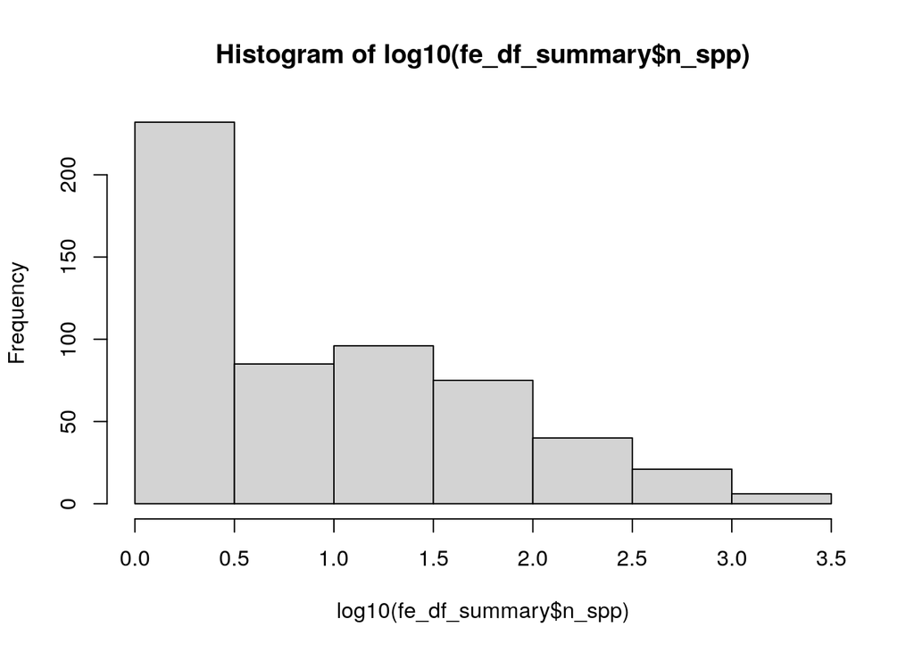

```r
fe_df_summary <- fe_df %>%
  group_by(fe_code) %>%
  summarize(n_spp = n_distinct(species))

hist(log10(fe_df_summary$n_spp))
```

```r
DT::datatable(fe_df_summary)
```

|  | fe_code | n_spp |
| --- | --- | --- |
| 1 | MOBmig_FECvhi_GENshort_TRPter_LENmed_WCOLben | 2626 |
| 2 | MOBses_FEChi_GENshort_TRPpri_LENmed_WCOLrf | 2244 |
| 3 | MOBmig_FECvhi_GENshort_TRPsec_LENmed_WCOLben | 2178 |
| 4 | MOBses_FEChi_GENshort_TRPpri_LENlg_WCOLrf | 2163 |
| 5 | MOBres_FECvhi_GENshort_TRPter_LENmed_WCOLben | 1345 |
| 6 | MOBmig_FECvhi_GENshort_TRPsec_LENsm_WCOLben | 1176 |
| 7 | MOBses_FEChi_GENshort_TRPpri_LENsm_WCOLrf | 875 |
| 8 | MOBres_FECvhi_GENshort_TRPsec_LENsm_WCOLben | 826 |
| 9 | MOBmig_FECvhi_GENshort_TRPter_LENlg_WCOLben | 822 |
| 10 | MOBmig_FECvhi_GENshort_TRPter_LENsm_WCOLben | 776 |

[output cut: 545 more lines]

## 3.3 Write out functional entities

```r
fe_out_df <- fe_df %>%
  select(species, fe_code, n_spp = n) %>%
  mutate(fe_id = as.integer(fe_code))

write_csv(fe_out_df, here('_output/functional_entities/species_fe.csv'))

fe_traits_df <- fe_df %>%
  select(fe_code, n_spp = n, mob, fec, gen, trp, len, wcol) %>%
  distinct()

write_csv(fe_traits_df, here('_output/functional_entities/fe_traits.csv'))
```